# Lesson 12 Adapated from Example 3.3: Optimizing Vitamin C

by Anny-Claude Joseph

Last compiled on 22 September, 2021

#### Review

What types of design are we learning in this section? *Generalized block designs/within block designs.*

#### Background

##### 1)

Ok. The researchers identified brand of orange juice (3 types) as a blocking variable. What are the characteristics of a blocking variable? *Go to PPT 3.* So the brand is just nuisance variable that will probably account for a lot of variation but! we aren’t studying juice brands.

At this point the authors fit the model for the randomized complete block design using effects encoding.*ASK THEM ABOUT THE HYPOTHESIS FOR THE MODEL WE ARE BUILDING. Make sure that they know how to make conclusions ABOUT THE MODEL based on the model information section in R first. REMEMBER TO STRESS THAT WE ASKING OURSELVES IS THERE A BENEFIT TO HAVING THE EXPLANATORY VARIABLES IN THE MODEL AND WHICH OF THE VARIABLES THEMSELVES ARE SIGNIFICANT.* There is code on how to build the two-variable anova. There is also code on how to make the interaction plot.

```r
# Create contrasts
contrasts(OJ1$Brand) = contr.sum
contrasts(OJ1$Temp) = contr.sum
levels(OJ1$Brand)
```

```
## [1] "GreatValue" "Meijer"     "MinuteMaid"
```

```r
levels(OJ1$Temp)
```

```
## [1] "Refrigerator" "Room"
```

```r
OJ1.lm <- lm(VitC~Brand+Temp, data=OJ1)
summary(OJ1.lm)
```

```
##
## Call:
## lm(formula = VitC ~ Brand + Temp, data = OJ1)
##
## Residuals:
##     1     2     3     4     5     6
## -0.06  0.06  0.15 -0.15 -0.09  0.09
##
## Coefficients:
##             Estimate Std. Error t value Pr(>|t|)
## (Intercept)  2.15333    0.07550  28.522  0.00123 **
## Brand1       0.19667    0.10677   1.842  0.20682
## Brand2      -0.05333    0.10677  -0.500  0.66696
## Temp1        0.09000    0.07550   1.192  0.35550
## ---
## Signif. codes:  0 '***' 0.001 '**' 0.01 '*' 0.05 '.' 0.1 ' ' 1
##
## Residual standard error: 0.1849 on 2 degrees of freedom
## Multiple R-squared:  0.7163, Adjusted R-squared:  0.2908
## F-statistic: 1.684 on 3 and 2 DF,  p-value: 0.3937
```

```r
anova(OJ1.lm)
```

|  | Df | Sum Sq | Mean Sq | F value | Pr(>F) |
| --- | --- | --- | --- | --- | --- |
| Brand | 2 | 0.1241333 | 0.06206667 | 1.814815 | 0.3552632 |
| Temp | 1 | 0.0486000 | 0.04860000 | 1.421053 | 0.3554966 |
| Residuals | 2 | 0.0684000 | 0.03420000 | NA | NA |

The authors also fit a two-way anova with an interaction. What does it mean for there to be an interaction between temperature and brand? What are the hypotheses for the interaction model? *We have reason to believe that the relationship between temperature and vitamin C is modified by brand.* *Go to R.*

```r
OJ1.interact.lm <- lm(VitC~Brand*Temp, data=OJ1)
summary(OJ1.interact.lm)
```

```
##
## Call:
## lm(formula = VitC ~ Brand * Temp, data = OJ1)
##
## Residuals:
## ALL 6 residuals are 0: no residual degrees of freedom!
##
## Coefficients:
##              Estimate Std. Error t value Pr(>|t|)
## (Intercept)   2.15333         NA      NA       NA
## Brand1        0.19667         NA      NA       NA
## Brand2       -0.05333         NA      NA       NA
## Temp1         0.09000         NA      NA       NA
## Brand1:Temp1 -0.06000         NA      NA       NA
## Brand2:Temp1  0.15000         NA      NA       NA
##
## Residual standard error: NaN on 0 degrees of freedom
## Multiple R-squared:      1,  Adjusted R-squared:    NaN
## F-statistic:   NaN on 5 and 0 DF,  p-value: NA
```

```r
anova(OJ1.interact.lm)
```

|  | Df | Sum Sq | Mean Sq | F value | Pr(>F) |
| --- | --- | --- | --- | --- | --- |
| Brand | 2 | 0.1241333 | 0.06206667 | NaN | NaN |
| Temp | 1 | 0.0486000 | 0.04860000 | NaN | NaN |
| Brand:Temp | 2 | 0.0684000 | 0.03420000 | NaN | NaN |
| Residuals | 0 | 0.0000000 | NaN | NA | NA |

Notice that there is only one observation for each treatment with each brand, the interaction and the error are completely confounded - which is why R is screaming at us. We can only carry out statistical tests of the effect of the explanatory variable in a randomized complete block design if we are willing to assume there is no interaction between the block and explanatory variable.

##### 2)

The authors then ask- well- how do we modify this study design to test for a statistically significant interaction if we have reason to believe that the relationship between temperature and vitamin C is modified by the brand of orange juice? What do you think? What do we do? . *Adding more observations would help! In other words they need replication of each treatment within each block*

*Go to PPT 4.*

This type of study design that will allow us to do this is known as a generalized block design. *Go to PPT 5 then Show Diagrams 1 and 2 on white board.*.

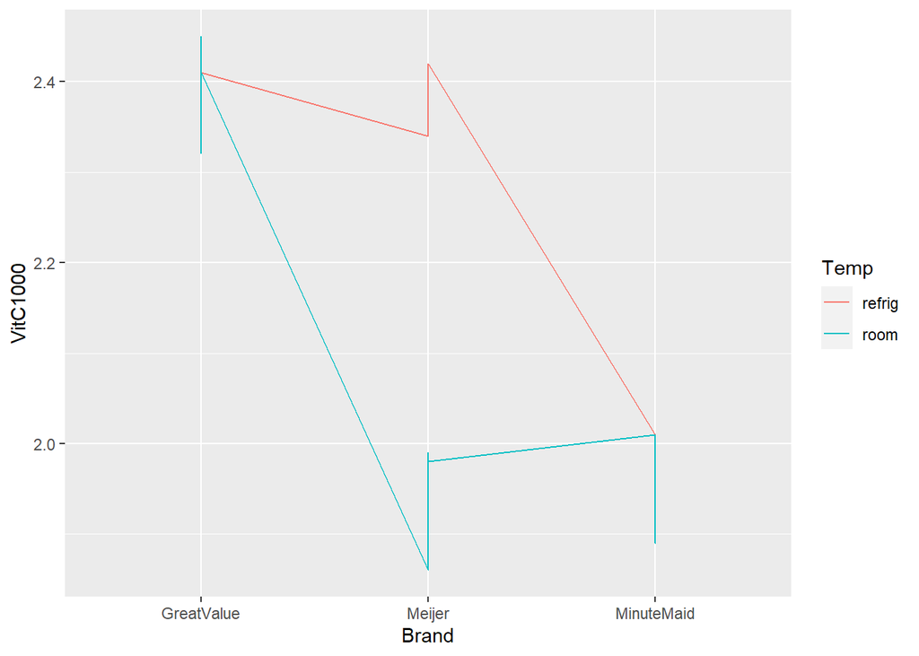

```r
OJ2 <- read.table('C:/Users/annyclaude.joseph/Desktop/MA376/OJ-n18.txt', header=T)
View(OJ2) # n = 18

# Tasks:
# a) Confirm that data are in long format
# b) Verify that categorical variables are 'factors'. If not, change to factors.
OJ2 <- OJ2 %>% mutate(Brand=as.factor(Brand),Temp=as.factor(Temp))

# Figure 3.3.8: Interaction plot
OJ2 %>% ggplot(aes(x=Brand, y=VitC1000, group=Temp, color=Temp))+ geom_line()
```

```r
# Create contrasts
contrasts(OJ2$Brand) = contr.sum
contrasts(OJ2$Temp) = contr.sum
levels(OJ2$Brand)
```

```
## [1] "GreatValue" "Meijer"     "MinuteMaid"
```

```r
levels(OJ2$Temp)
```

```
## [1] "refrig" "room"
```

```r
# Interaction Model
OJ2.interact.lm <- lm(VitC1000~Brand*Temp, data=OJ2)
summary(OJ2.interact.lm)
```

```
##
## Call:
## lm(formula = VitC1000 ~ Brand * Temp, data = OJ2)
##
## Residuals:
##      Min       1Q   Median       3Q      Max
## -0.08333 -0.02917  0.01667  0.03333  0.05667
##
## Coefficients:
##              Estimate Std. Error t value Pr(>|t|)
## (Intercept)   2.17833    0.01258 173.116  < 2e-16 ***
## Brand1        0.21167    0.01780  11.895 5.33e-08 ***
## Brand2       -0.01333    0.01780  -0.749 0.468130
## Temp1         0.07722    0.01258   6.137 5.04e-05 ***
## Brand1:Temp1 -0.08056    0.01780  -4.527 0.000694 ***
## Brand2:Temp1  0.14444    0.01780   8.117 3.24e-06 ***
## ---
## Signif. codes:  0 '***' 0.001 '**' 0.01 '*' 0.05 '.' 0.1 ' ' 1
##
## Residual standard error: 0.05339 on 12 degrees of freedom
## Multiple R-squared:  0.9591, Adjusted R-squared:  0.942
## F-statistic: 56.27 on 5 and 12 DF,  p-value: 6.512e-08
```

```r
anova(OJ2.interact.lm)
```

|  | Df | Sum Sq | Mean Sq | F value | Pr(>F) |
| --- | --- | --- | --- | --- | --- |
| Brand | 2 | 0.5059000 | 0.25295000 | 88.75439 | 6.446316e-08 |
| Temp | 1 | 0.1073389 | 0.10733889 | 37.66277 | 5.044649e-05 |
| Brand:Temp | 2 | 0.1886111 | 0.09430556 | 33.08967 | 1.307783e-05 |
| Residuals | 12 | 0.0342000 | 0.00285000 | NA | NA |

*ASK THEM ABOUT THE HYPOTHESIS FOR THE MODEL WE ARE BUILDING. SPEND TIME ON THE RESULTS FROM THE ANOVA. REMIND THEM THAT WE ONLY WANT TO INTERPRET THE INTERACTION AND NOT THE MAIN EFFECTS. BE SURE TO ASK THEM HOW THEY WOULD DECIDE ON WHICH MODEL IS PREFERRED.*.

##### 3)

Suppose there was a second explanatory variable, type of water (distilled/tap). Each glass of orange juice can be made with either distilled or tap water. The researchers try yet another type of design, the within block factorial design. What are the characteristics of this design? *We are assuming that each block contains all combinations of treatments*

This means, we have temperature and the type of water as explanatory variables, with brand as a blocking variable (nuisance variable- we aren’t studying juice brands). Whe can carry out a 2x2 factorial design of our explanatory variables but, within each block, i.e. four treatments within each of the three blocks. *Show Diagram 3 on white board.*

Let’s look at the partial anova table *Go to PPT6.*. Notice that the authors fit a model in which they assume that there is no interaction between the treatments (water-temperature combinations) and brand the blocking variable. This may not be an appropriate assumption.